# Chapter 1 In-Class R Demo: What Is a Time Series?

## Demo Goal

You will use real and simulated series to see why time order matters.

Reference anchor: introductory time-series examples and decomposition ideas from Brockwell–Davis, Cryer–Chan, and Shumway–Stoffer.

```r
set.seed(311)
par(mfrow = c(1, 1))
```

## 1. Cross-Sectional Data Versus Time Series

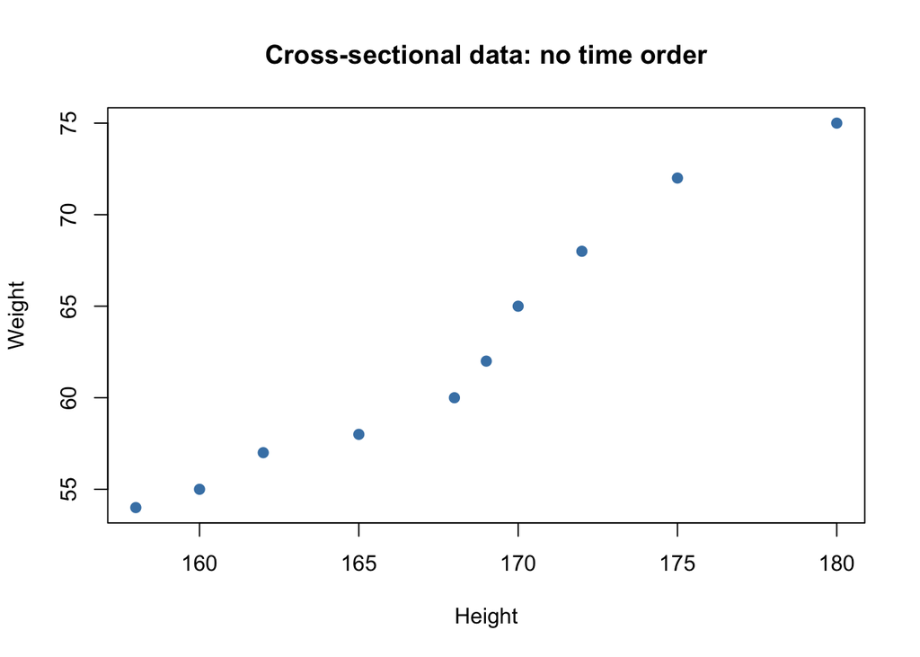

```r
height <- c(165, 170, 160, 175, 168, 172, 158, 180, 169, 162)
weight <- c(58, 65, 55, 72, 60, 68, 54, 75, 62, 57)
plot(height, weight, pch = 19, col = "steelblue",
     main = "Cross-sectional data: no time order",
     xlab = "Height", ylab = "Weight")
```

Questions:

- What does one point represent?
- Would swapping the order of the rows change the meaning?

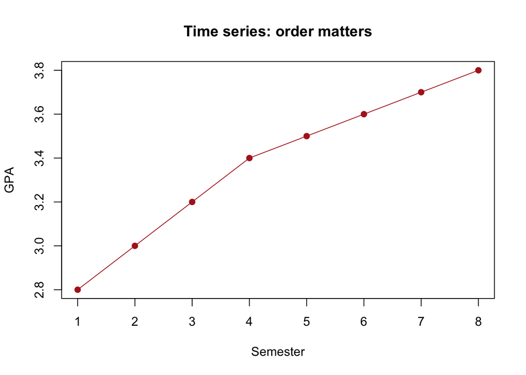

```r
gpa <- c(2.8, 3.0, 3.2, 3.4, 3.5, 3.6, 3.7, 3.8)
plot.ts(gpa, type = "o", pch = 19, col = "firebrick",
        main = "Time series: order matters",
        xlab = "Semester", ylab = "GPA")
```

Questions:

- What does the line add that a scatterplot does not?
- What pattern would be lost if the order were shuffled?

## 2. Trend, Seasonality, and Noise

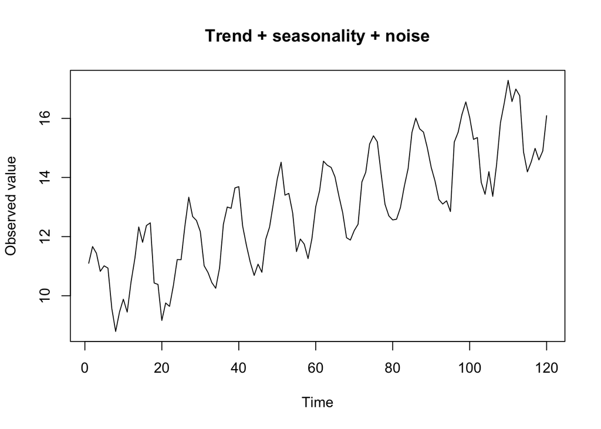

```r
n <- 120
t <- 1:n
trend <- 0.05 * t
season <- 1.5 * sin(2 * pi * t / 12)
noise <- rnorm(n, 0, 0.4)
y <- 10 + trend + season + noise

plot.ts(y, main = "Trend + seasonality + noise",
        ylab = "Observed value", xlab = "Time")
```

Questions:

- Which part looks like trend?
- Which part repeats?
- Which part is unpredictable?

## 3. Classical Decomposition

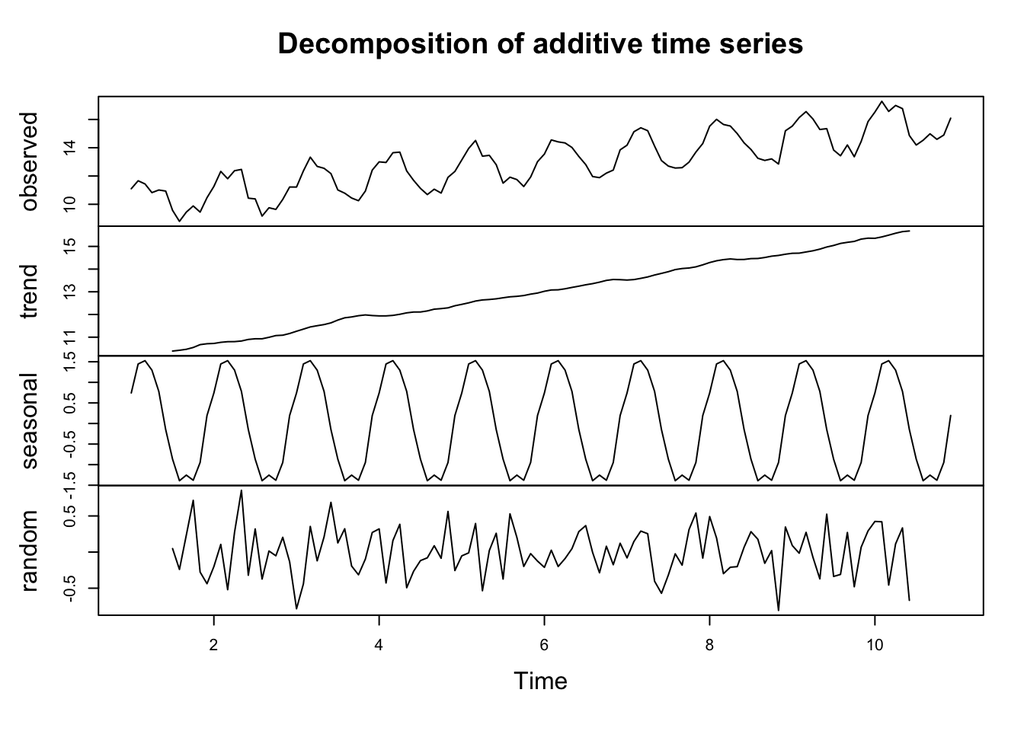

```r
y_ts <- ts(y, frequency = 12)
d <- decompose(y_ts, type = "additive")
plot(d)
```

Try it yourself:

- Increase the noise standard deviation from `0.4` to `1.5`.
- Rerun the plot and decomposition.
- Can you still see the trend and seasonality easily?
- Replace `decompose()` by `stl(y_ts, s.window = "periodic")` and compare.

## 4. Built-In Data: AirPassengers

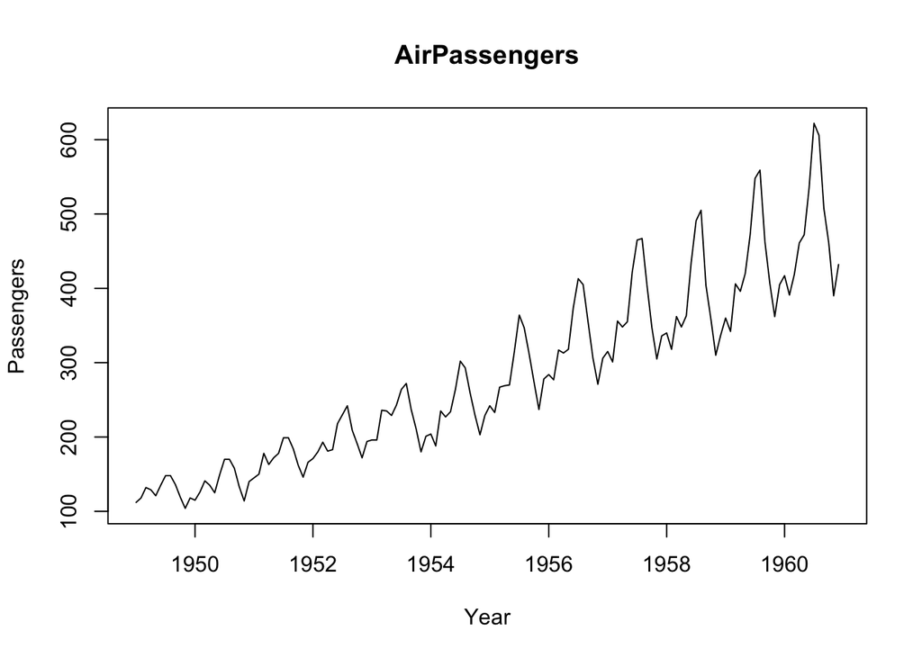

```r
plot(AirPassengers, main = "AirPassengers",
     ylab = "Passengers", xlab = "Year")
```

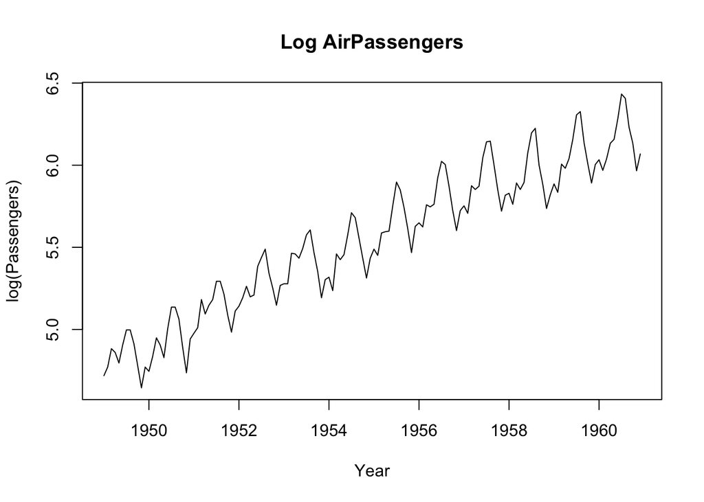

```r
plot(log(AirPassengers), main = "Log AirPassengers",
     ylab = "log(Passengers)", xlab = "Year")
```

Questions:

- Why does the seasonal variation grow over time in the original plot?
- Why does the log transformation help?

## 5. Inspecting a ts Object

```r
AP <- AirPassengers
start(AP)      # first observation: year and month
```

```
## [1] 1949    1
```

```r
end(AP)        # last observation
```

```
## [1] 1960   12
```

```r
frequency(AP)  # observations per year; 12 = monthly
```

```
## [1] 12
```

```r
class(AP)      # "ts"
```

```
## [1] "ts"
```

```r
length(AP)     # number of observations
```

```
## [1] 144
```

```r
head(AP)       # first 6 observations
```

```
##      Jan Feb Mar Apr May Jun
## 1949 112 118 132 129 121 135
```

```r
tail(AP)       # last 6 observations
```

```
##      Jul Aug Sep Oct Nov Dec
## 1960 622 606 508 461 390 432
```

Questions:

- How does R know that the first value is January 1949?
- What would `frequency()` be for quarterly data?

## 6. Annual Totals and Seasonal Boxplots

`aggregate()` turns a monthly series into yearly totals, which hides the seasonal pattern and shows the long-run trend. `cycle()` gives the month (1 to 12) of each observation, so `boxplot(AP ~ cycle(AP))` puts all Januaries together, all Februaries together, and so on.

```r
AP_annual <- aggregate(AP)  # yearly totals
AP_annual
```

```
## Time Series:
## Start = 1949
## End = 1960
## Frequency = 1
##  [1] 1520 1676 2042 2364 2700 2867 3408 3939 4421 4572 5140 5714
```

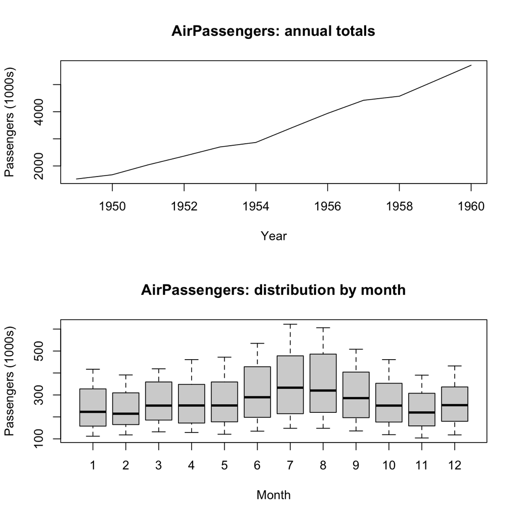

```r
par(mfrow = c(2, 1))
plot(AP_annual, main = "AirPassengers: annual totals",
     xlab = "Year", ylab = "Passengers (1000s)")
boxplot(AP ~ cycle(AP), main = "AirPassengers: distribution by month",
        xlab = "Month", ylab = "Passengers (1000s)")
```

```r
par(mfrow = c(1, 1))
```

`window()` cuts out part of a series, so we can compare early and late years.

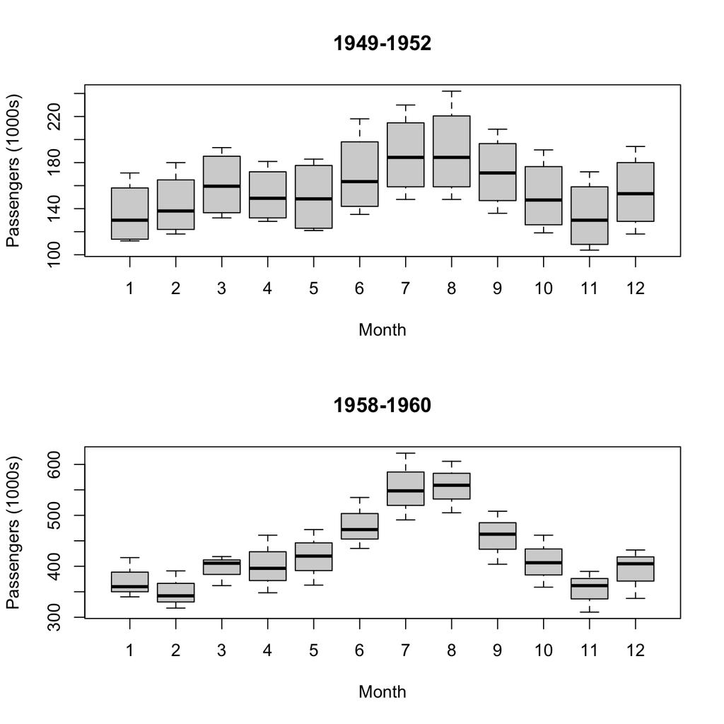

```r
AP_early <- window(AP, start = c(1949, 1), end = c(1952, 12))
AP_late  <- window(AP, start = c(1958, 1), end = c(1960, 12))

par(mfrow = c(2, 1))
boxplot(AP_early ~ cycle(AP_early), main = "1949-1952",
        xlab = "Month", ylab = "Passengers (1000s)")
boxplot(AP_late ~ cycle(AP_late), main = "1958-1960",
        xlab = "Month", ylab = "Passengers (1000s)")
```

```r
par(mfrow = c(1, 1))
```

Questions:

- Which months are busiest? Is that the same early and late?
- Has the size of the seasonal swing changed? What does that suggest about an additive or a multiplicative model?

## 7. Another Monthly Series: UK Road Casualties

`UKDriverDeaths` is the monthly number of car drivers killed or seriously injured in Great Britain, January 1969 to December 1984. Wearing a seat belt became compulsory on 31 January 1983.

```r
drivers <- UKDriverDeaths
start(drivers); end(drivers); frequency(drivers)
```

```
## [1] 1969    1
```

```
## [1] 1984   12
```

```
## [1] 12
```

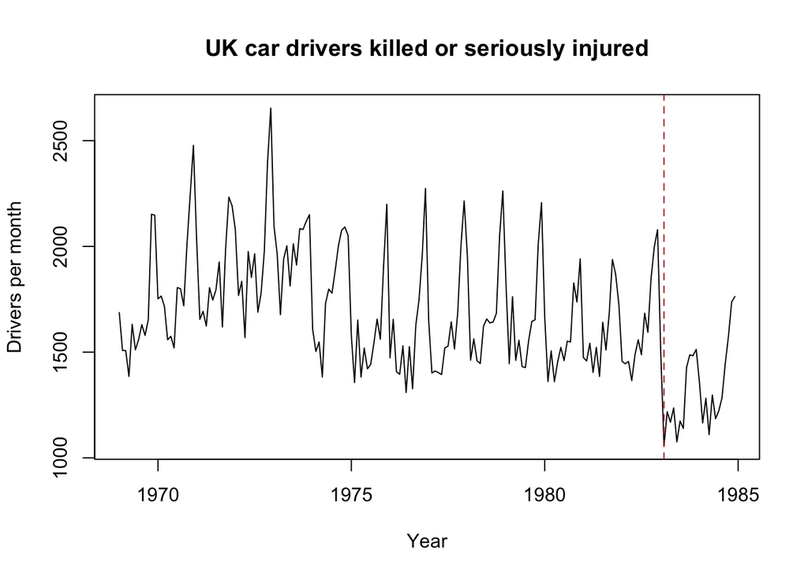

```r
plot(drivers, main = "UK car drivers killed or seriously injured",
     xlab = "Year", ylab = "Drivers per month")
abline(v = 1983 + 1/12, col = "firebrick", lty = 2)  # seat belt law, Feb 1983
```

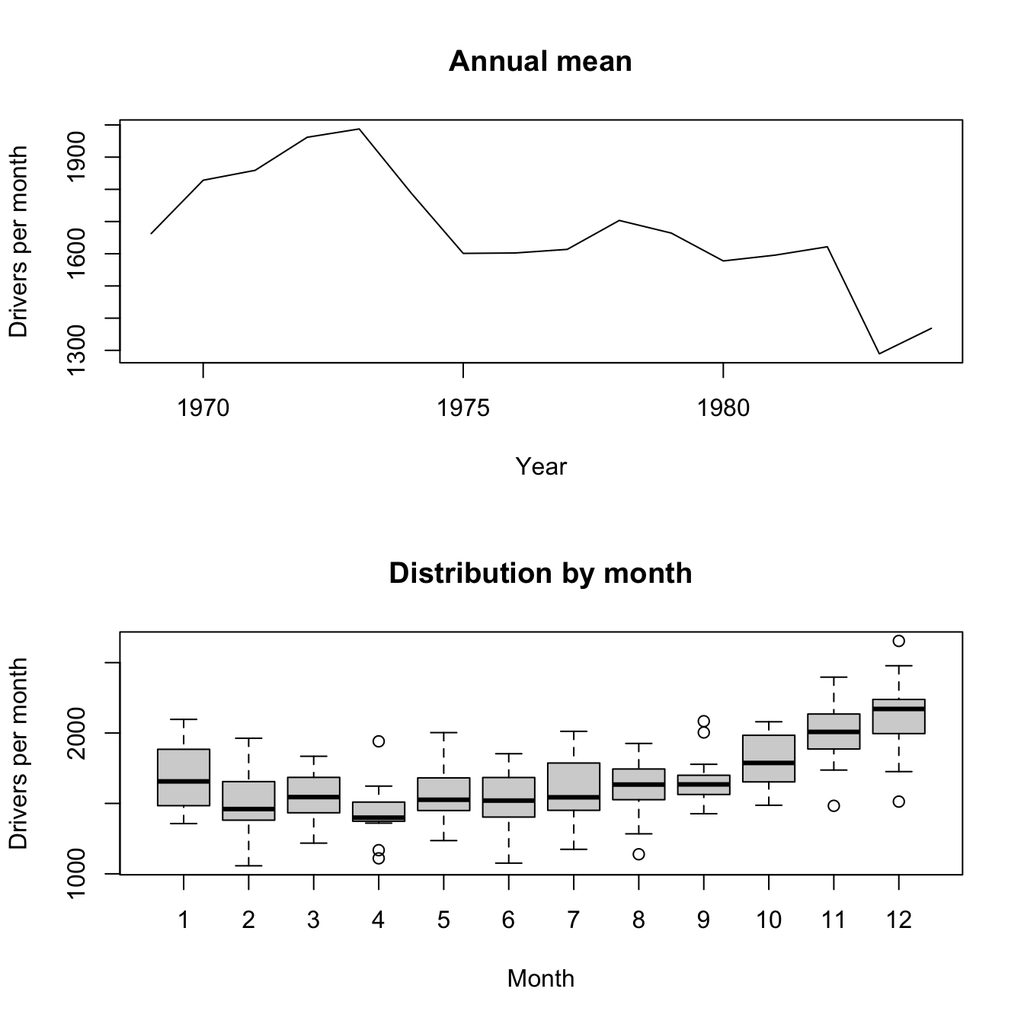

```r
par(mfrow = c(2, 1))
plot(aggregate(drivers, FUN = mean), main = "Annual mean",
     xlab = "Year", ylab = "Drivers per month")
boxplot(drivers ~ cycle(drivers), main = "Distribution by month",
        xlab = "Month", ylab = "Drivers per month")
```

```r
par(mfrow = c(1, 1))

# Each month's mean relative to the overall mean
round(tapply(drivers, cycle(drivers), mean) / mean(drivers), 2)
```

```
##    1    2    3    4    5    6    7    8    9   10   11   12
## 1.02 0.90 0.93 0.86 0.94 0.91 0.95 0.96 0.99 1.08 1.20 1.27
```

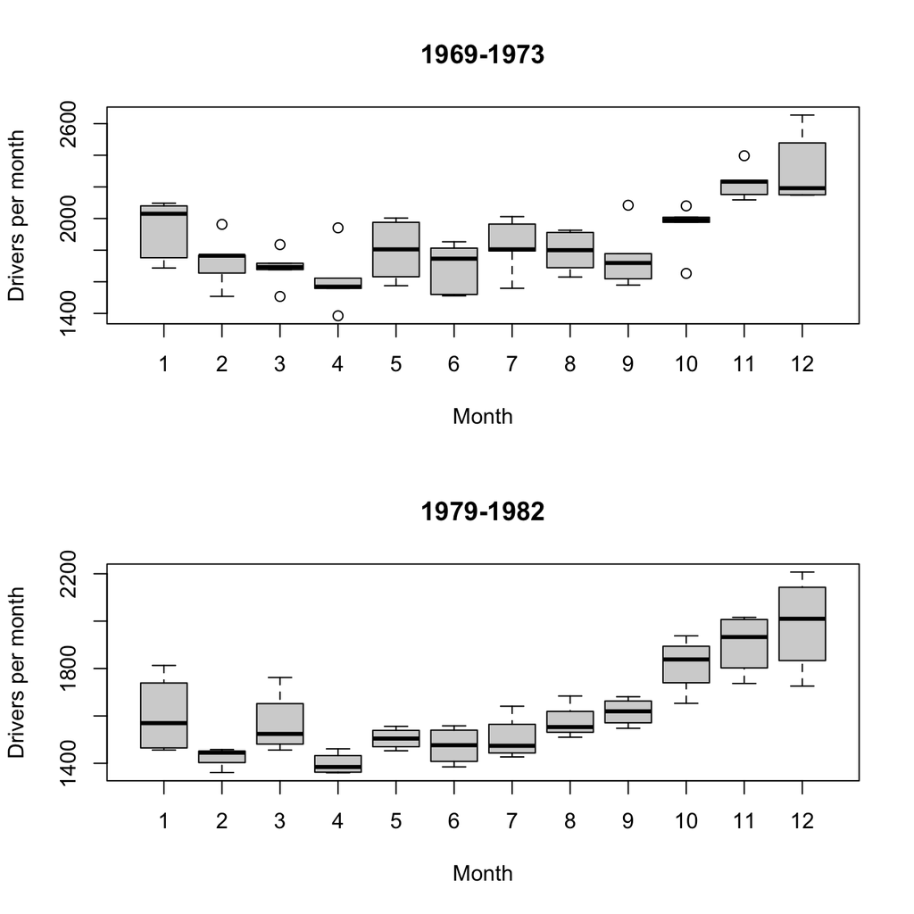

```r
drivers_early <- window(drivers, start = c(1969, 1), end = c(1973, 12))
drivers_late  <- window(drivers, start = c(1979, 1), end = c(1982, 12))

par(mfrow = c(2, 1))
boxplot(drivers_early ~ cycle(drivers_early), main = "1969-1973",
        xlab = "Month", ylab = "Drivers per month")
boxplot(drivers_late ~ cycle(drivers_late), main = "1979-1982",
        xlab = "Month", ylab = "Drivers per month")
```

```r
par(mfrow = c(1, 1))
```

Questions:

- Which months have the most casualties, and why might that be?
- What happens to the level after February 1983? Is that a trend, a season, or something else?

## 8. Several Series Together

`mdeaths`, `fdeaths` and `ldeaths` are monthly deaths from bronchitis, emphysema and asthma in the UK, 1974-1979, for males, females and in total. `cbind()` combines them, and `plot()` draws one panel per series.

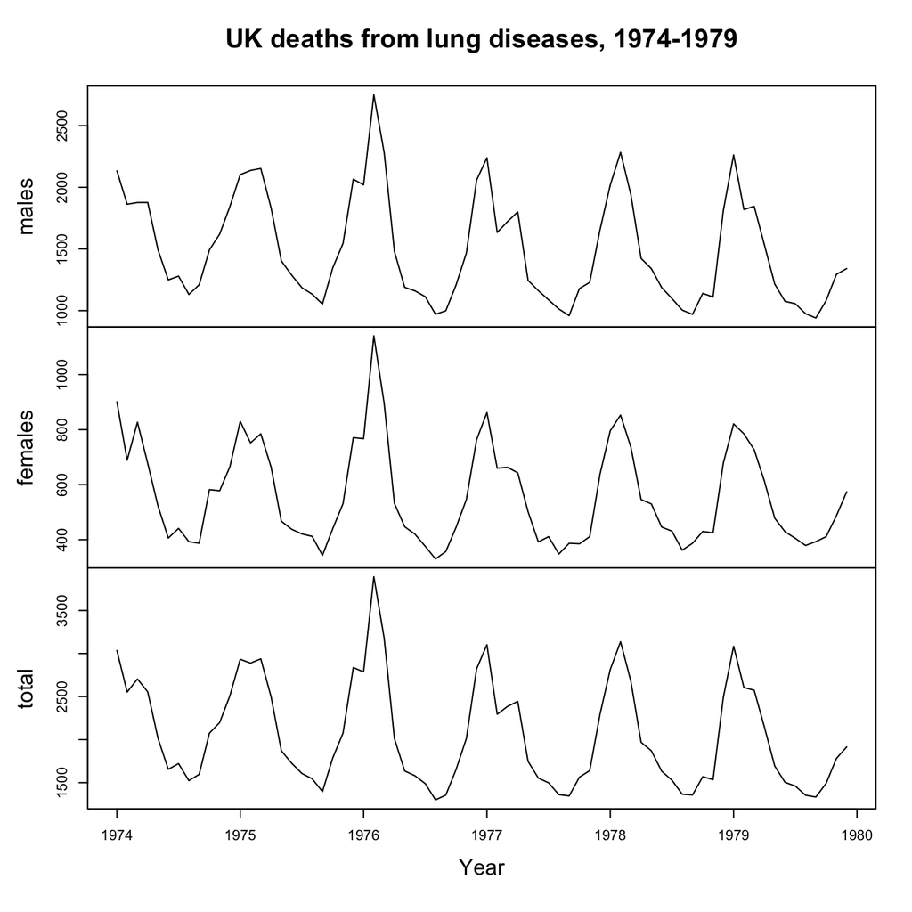

```r
plot(cbind(males = mdeaths, females = fdeaths, total = ldeaths),
     main = "UK deaths from lung diseases, 1974-1979", xlab = "Year")
```

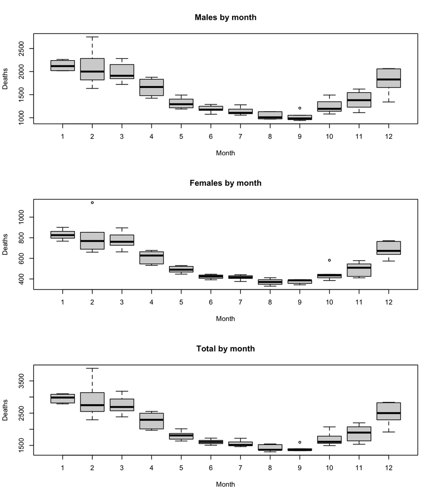

```r
par(mfrow = c(3, 1))
boxplot(mdeaths ~ cycle(mdeaths), main = "Males by month",
        xlab = "Month", ylab = "Deaths")
boxplot(fdeaths ~ cycle(fdeaths), main = "Females by month",
        xlab = "Month", ylab = "Deaths")
boxplot(ldeaths ~ cycle(ldeaths), main = "Total by month",
        xlab = "Month", ylab = "Deaths")
```

```r
par(mfrow = c(1, 1))

aggregate(cbind(males = mdeaths, females = fdeaths, total = ldeaths))  # yearly totals
```

```
## Time Series:
## Start = 1974
## End = 1979
## Frequency = 1
##      males females total
## 1974 19071    7069 26140
## 1975 19247    6854 26101
## 1976 18697    7021 25718
## 1977 16927    6302 23229
## 1978 17329    6622 23951
## 1979 16437    6501 22938
```

Questions:

- Do the three series share the same seasonal pattern?
- Is there a trend, or mainly seasonality?

## 9. Deterministic and Stochastic Trends

A least-squares line for `LakeHuron` (a deterministic trend, as in the notes), next to three random walks $X_t = X_{t-1} + \epsilon_t$, $X_0 = 0$, with Gaussian iid white noise $\epsilon_t \sim N(0, 1)$ as steps, which have mean $0$ for every $t$.

```r
t <- seq_along(LakeHuron)
fit_lake <- lm(LakeHuron ~ t)
coef(fit_lake)
```

```
##  (Intercept)            t
## 580.20203661  -0.02420111
```

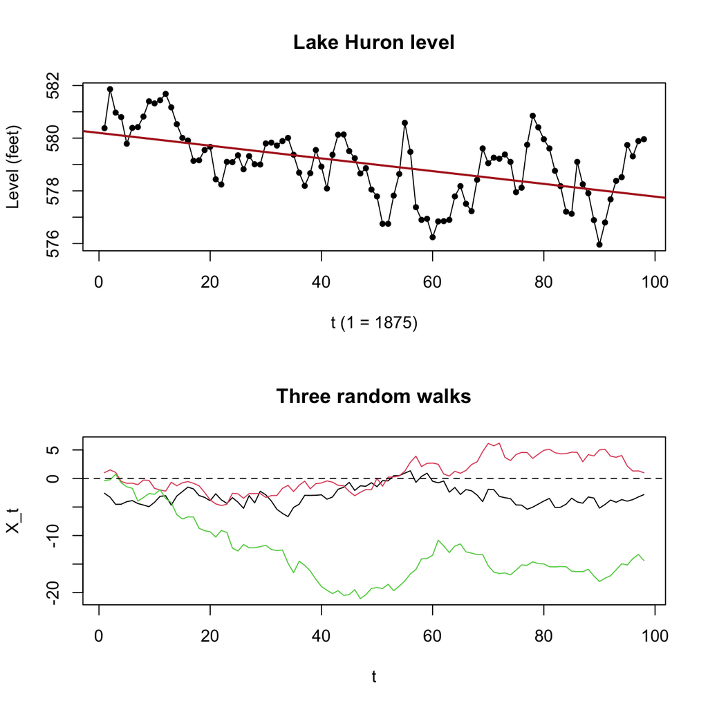

```r
walks <- replicate(3, cumsum(rnorm(98)))
par(mfrow = c(2, 1))
plot(as.numeric(LakeHuron), type = "o", pch = 20, main = "Lake Huron level",
     xlab = "t (1 = 1875)", ylab = "Level (feet)")
abline(fit_lake, col = "firebrick", lwd = 2)
matplot(walks, type = "l", lty = 1, main = "Three random walks",
        xlab = "t", ylab = "X_t")
abline(h = 0, lty = 2)
```

```r
par(mfrow = c(1, 1))
```

Questions:

- Do the random walks look as if they had trends? Do they all go the same way?
- What would we have to believe to extrapolate the Lake Huron line to 2030?